# **Detecting Malaria Parasites in Blood Smear Microscopy**

### Plotting the Confusion Matrix

The helper below generates the confusion matrix plot and renders the full classification report as a markdown table

*(A **confusion matrix** is a 2-class summary of the test set: how many actual-Parasitized cells did we correctly call Parasitized, how many actual-Parasitized cells did we wrongly call Uninfected, and so on. It expands one accuracy number into four:* *- **TP** (true positive) — actually Parasitized, predicted Parasitized.* *- **FN** (false negative) — actually Parasitized, predicted Uninfected. **Clinically the worst kind of error** — a missed infection.* *- **FP** (false positive) — actually Uninfected, predicted Parasitized. A false alarm.* *- **TN** (true negative) — actually Uninfected, predicted Uninfected.*

*The **classification report** then turns those counts into per-class precision (when you say 'Parasitized', how often are you right?), recall (of all the actual Parasitized cells, how many did you catch?), and F1 (the harmonic mean of the two).)*

```python
# ─── Helper: plot the confusion matrix and print the classification report ───
# Inputs  : model       — a trained Keras model with softmax output.
#           on_data     — input images to predict on (e.g. test_images_norm).
#           true_labels — INTEGER labels (not one-hot) aligned with on_data.
#           titled      — title to use for the figure and the report header.
# Outputs : nothing returned — produces a heatmap figure + a Markdown report.
# Why keyword-only args? Forces every caller to write
# `plot_confusion_matrix(model, on_data=..., true_labels=...)` — much harder
# to mix up the order of two NumPy arrays that way.
def plot_confusion_matrix(model, *, on_data: np.ndarray, true_labels: np.ndarray, titled: str = 'Confusion Matrix'):
    # * marks the following params as keyword-only — callers MUST write
    # `on_data=..., true_labels=..., titled=...`. This mirrors Swift-style
    # labelled arguments and makes call sites self-documenting.

    # model.predict() returns probability vectors of shape (N, 2). argmax(axis=1)
    # picks the class with the highest probability per row, giving shape (N,).
    y_pred = np.argmax(model.predict(on_data), axis=1)
    # sklearn's confusion_matrix returns a 2D array:
    #   cm[i, j] = number of samples with true=i that were predicted=j
    # Diagonal = correct; off-diagonal = errors.
    cm = confusion_matrix(true_labels, y_pred)

    # Heatmap visualisation — annot=True writes the count in each cell,
    # fmt='d' formats those counts as integers.
    plt.figure(figsize=(6, 5))
    sns.heatmap(cm, annot=True, fmt='d', cmap='Blues',
                xticklabels=class_names, yticklabels=class_names)
    plt.title(titled)
    plt.ylabel('True Label')
    plt.xlabel('Predicted Label')
    plt.tight_layout()
    plt.show()

    # classification_report produces precision/recall/F1 per class. output_dict=True
    # returns a nested dict rather than a formatted string, which is easier to
    # render as a markdown table below.
    report = classification_report(
        true_labels, y_pred,
        target_names=class_names,
        output_dict=True,
      )

    # Build the table rows from the dict. Precision = TP/(TP+FP), Recall = TP/(TP+FN),
    # F1 = harmonic mean. Support = number of true samples of that class.
    rows = ""                                  # accumulator for the markdown table body
    for cls in class_names:                    # one row per class — Parasitized then Uninfected
        r = report[cls]                        # dict of metrics for this class
        rows += (f"| {cls} | `{r['precision']:.3f}` | `{r['recall']:.3f}` "
                 f"| `{r['f1-score']:.3f}` | {int(r['support'])} |\n")

    # Render the heatmap figure together with a per-class metrics table and the
    # overall accuracy. The reader can read these side-by-side.
    say(this=f"""
**Classification Report — {titled}**

| Class | Precision | Recall | F1-score | Support |
|-------|-----------|--------|----------|---------|
{rows}
| **Overall Accuracy** | | | **`{report['accuracy']:.3f}`** | {int(report['macro avg']['support'])} |
    """)
```

```python
# ─── Helper: ROC + Precision-Recall plot for any Keras classifier ────────────
# Inputs (one of two call modes):
#   plot_roc_pr_keras(model, on_data=<np.ndarray>, true_labels=<np.ndarray>, titled='...')
#       — for the in-memory NumPy path used by the custom CNNs (Models 1-3, VGG16).
#   plot_roc_pr_keras(model, test_gen=<DirectoryIterator>, titled='...')
#       — for the `flow_from_directory` path used by EfficientNet / MobileNet.
# Output : prints a side-by-side ROC + PR figure plus a markdown line with
#          ROC AUC and Average Precision. Returns (roc_auc, ap).
# Why a single helper for two paths? It keeps every per-model invocation cell a
# one-liner regardless of which data plumbing the model uses.
from sklearn.metrics import (
    roc_curve, precision_recall_curve, auc, average_precision_score,
)

def _draw_roc_pr(y_true_binary, y_scores_pos, *, titled):
    """Render the ROC and PR curves once we have aligned binary labels + scores."""
    fpr, tpr, _    = roc_curve(y_true_binary, y_scores_pos)
    roc_auc        = auc(fpr, tpr)
    precision, recall, _ = precision_recall_curve(y_true_binary, y_scores_pos)
    ap             = average_precision_score(y_true_binary, y_scores_pos)

    fig, (ax1, ax2) = plt.subplots(1, 2, figsize=(12, 4.5))
    # ROC: TPR vs FPR. Diagonal is the random-classifier baseline.
    ax1.plot(fpr, tpr, label=f'AUC = {roc_auc:.4f}', linewidth=2)
    ax1.plot([0, 1], [0, 1], '--', color='grey', label='Chance')
    ax1.set_xlabel('False Positive Rate'); ax1.set_ylabel('True Positive Rate')
    ax1.set_title(f'{titled} — ROC')
    ax1.legend(loc='lower right'); ax1.grid(alpha=0.3)

    # Precision-Recall: more informative on imbalanced data; on this 50/50
    # dataset it tells a very similar story to ROC, but it is still the
    # canonical curve for a screening application.
    ax2.plot(recall, precision, label=f'AP = {ap:.4f}', linewidth=2)
    ax2.set_xlabel('Recall'); ax2.set_ylabel('Precision')
    ax2.set_title(f'{titled} — Precision–Recall')
    ax2.legend(loc='lower left'); ax2.grid(alpha=0.3)
    plt.tight_layout(); plt.show()

    say(this=f"**{titled}** — ROC AUC: `{roc_auc:.4f}`, Average Precision: `{ap:.4f}`")
    return roc_auc, ap


def plot_roc_pr_keras(model, *, on_data=None, true_labels=None, test_gen=None, titled='Model'):
    """ROC + PR for a Keras classifier. Pass either (on_data, true_labels) OR test_gen."""
    if test_gen is not None:
        # Generator path: rewind so predict() walks the test set in deterministic order.
        test_gen.reset()
        probs   = model.predict(test_gen, verbose=0)
        # `flow_from_directory` reports class indices alphabetically — for this
        # dataset that is parasitized=0, uninfected=1. Probability of the
        # *positive* class (Parasitized) is column 0.
        scores_pos = probs[:, 0]
        labels_int = test_gen.classes
    else:
        if on_data is None or true_labels is None:
            raise ValueError("Pass either test_gen=... or both on_data=... and true_labels=...")
        probs   = model.predict(on_data, verbose=0)
        scores_pos = probs[:, 0]
        labels_int = true_labels

    # Binary indicator: 1 = Parasitized (positive class for malaria detection).
    y_true_binary = (np.asarray(labels_int) == 0).astype(int)
    return _draw_roc_pr(y_true_binary, scores_pos, titled=titled)
```

### Apply the helper to the just-trained base model.

*(One-line call — all the heavy lifting is inside the helper above.)*

```
82/82 ━━━━━━━━━━━━━━━━━━━━ 0s 3ms/step
```

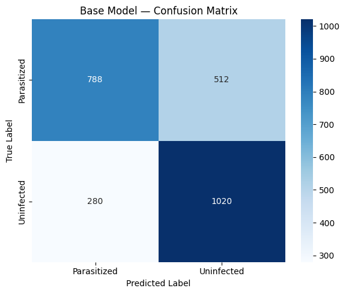

**Classification Report — Base Model — Confusion Matrix**

| Class | Precision | Recall | F1-score | Support |
| --- | --- | --- | --- | --- |
| Parasitized | `0.738` | `0.606` | `0.666` | 1300 |
| Uninfected | `0.666` | `0.785` | `0.720` | 1300 |

| **Overall Accuracy** | | | **`0.695`** | 2600 |

```python
# ─── Render the Base Model's confusion matrix and classification report ─────
# Note we pass the INTEGER labels (test_labels), NOT the one-hot version,
# because the helper calls sklearn's confusion_matrix which expects integers.
plot_confusion_matrix(base_model, on_data=test_images_norm, true_labels=test_labels, titled='Base Model — Confusion Matrix')
```

### Understanding the ROC Curve

The confusion matrix above summarises predictions at a **single decision threshold** — the default of 0.5. Any image where the model outputs `P(Parasitized) ≥ 0.5` gets predicted as Parasitized; everything else gets predicted as Uninfected. But **0.5 is just a convention**, not a law. A 0.3 threshold would flag more cells as Parasitized (catching more true infections at the cost of more false alarms); a 0.7 threshold would flag fewer (missing some infections but being more confident when it does flag). The right threshold depends on the *cost* of each kind of error, which is a clinical decision, not a mathematical one.

The ROC (**Receiver Operating Characteristic**) curve visualises this trade-off. It plots, as the threshold sweeps from 1.0 down to 0.0, two rates:

- **True Positive Rate (TPR)**, also called **Recall** or **Sensitivity**, on the y-axis: TPR = TP / (TP + FN) — the fraction of *actually-infected* cells the model correctly catches.
- **False Positive Rate (FPR)**, on the x-axis: FPR = FP / (FP + TN) — the fraction of *actually-uninfected* cells the model wrongly flags as infected.

Every point on the curve corresponds to one threshold value. Moving the threshold down from 1.0 to 0.0 walks you from `(0, 0)` (flag nothing — 0 TPR, 0 FPR) to `(1, 1)` (flag everything — 100% TPR, 100% FPR). The shape of the curve between these two extremes tells you how well the model separates the classes.

*(Why the name? "Receiver Operating Characteristic" is World-War-II-era radar jargon: how good is a radar receiver at telling enemy planes from background noise as you tweak its sensitivity dial? The same idea — a classifier's behaviour as the sensitivity dial moves — applies directly to a malaria detector.)*

**Reading the curve:**

| Shape | What it means |
| --- | --- |
| Close to the top-left corner `(0, 1)` | Excellent — high TPR achievable at low FPR |
| Diagonal line from `(0,0)` to `(1,1)` | Random guessing — the model has no discriminative power |
| Below the diagonal | Worse than random — usually a bug (swapped labels, inverted scores) |

**AUC (Area Under Curve)** is the single-number summary of a ROC curve. It ranges from 0 (always wrong) through 0.5 (random) to 1.0 (perfect). Interpretation:

- **AUC = 0.5** → no better than a coin flip
- **AUC ≈ 0.7** → acceptable for many tasks
- **AUC ≈ 0.9** → good medical-imaging performance
- **AUC ≥ 0.95** → excellent; comparable to human expert

A useful property of AUC is that it equals the probability that the model, given one random Parasitized cell and one random Uninfected cell, assigns the Parasitized one a higher score. It's a threshold-free measure of ranking quality.

**Why this matters clinically.** For malaria screening, missing an infection (False Negative) is worse than a false alarm (False Positive) — treatment is inexpensive, an untreated infection can kill. So you would deliberately pick a threshold *below* 0.5 to shift the operating point toward higher TPR (more recall on Parasitized), accepting the cost of a higher FPR. The ROC curve lets you pick that threshold *explicitly* rather than leaving it at the default. The Key Questions block at the end of this section works through the code for doing exactly that on the Base Model.

**Related: the Precision-Recall Curve.** For heavily imbalanced datasets, ROC can be misleading — a large True Negative count dampens FPR even when precision is bad. The **Precision-Recall curve** (precision on y-axis, recall on x-axis) is more informative when positive cases are rare. For this malaria dataset (≈ 50/50 class balance), ROC and PR curves tell similar stories, but real-world screening populations often have < 5% infection rates where PR curves reveal problems ROC curves hide.

*(Take-away: a confusion matrix is a snapshot at one threshold; an ROC curve is the **whole movie** of how the model behaves across all thresholds. They answer different questions and are best used together.)*

### Plotting the Train and Validation Curves

The helper below plots both accuracy and loss curves, then renders a summary table of key training statistics.

*(Why both? **Loss** is what we directly optimise (smooth, sensitive). **Accuracy** is what humans care about (lumpy, easier to read). Looking at both side-by-side makes it obvious whether the model is still learning, has converged, or has started to overfit.)*

```python
# ─── Helper: plot training curves and print a one-glance training summary ────
# Inputs  : history — the History object returned by model.fit().
#           titled  — heading for the figure and the summary table.
# Outputs : nothing returned — draws a 1×2 figure and prints a Markdown table.
# Use this AFTER training to diagnose overfitting / underfitting visually.
def plot_history(history, *, titled: str = 'Model'):
    # Two subplots side by side — accuracy on the left, loss on the right.
    # Looking at both together reveals overfitting more clearly than either alone.
    fig, (ax1, ax2) = plt.subplots(1, 2, figsize=(12, 4))

    # Accuracy curves — training vs validation over epochs.
    # Healthy curves: both rise together, stay close.
    # Overfitting:    train rises, val plateaus or falls.
    ax1.plot(history.history['accuracy'],     label='Train Accuracy')
    ax1.plot(history.history['val_accuracy'], label='Val Accuracy')
    ax1.set_title(f'{titled} — Accuracy')
    ax1.set_xlabel('Epoch'); ax1.set_ylabel('Accuracy')
    ax1.legend()

    # Loss curves — should DECREASE over epochs. Loss is what's directly
    # optimised, so its curves are smoother than the noisier accuracy.
    ax2.plot(history.history['loss'],     label='Train Loss')
    ax2.plot(history.history['val_loss'], label='Val Loss')
    ax2.set_title(f'{titled} — Loss')
    ax2.set_xlabel('Epoch'); ax2.set_ylabel('Loss')
    ax2.legend()

    plt.tight_layout()
    plt.show()

    # Extract summary stats from the history dict.
    best_val_acc    = max(history.history['val_accuracy'])   # peak generalisation
    best_val_loss   = min(history.history['val_loss'])       # minimum val loss (what EarlyStopping watches)
    final_train_acc = history.history['accuracy'][-1]        # final epoch's training accuracy
    # Gap between final train and best val accuracy = overfitting indicator.
    # > 5% gap typically signals the model is memorising training data beyond
    # what generalises to the validation set.
    gap             = final_train_acc - best_val_acc
    # Cheap visual flag so the reader can see overfitting at a glance.
    gap_flag        = '⚠️ possible overfitting' if gap > 0.05 else '✅ well generalised'

    say(this=f"""
**Training summary — {titled}**

| Metric | Value |
|--------|-------|
| Best val accuracy  | `{best_val_acc:.4f}` |
| Best val loss      | `{best_val_loss:.4f}` |
| Final train acc    | `{final_train_acc:.4f}` |
| Train / val gap    | `{gap:.4f}` — {gap_flag} |
| Total epochs run   | `{len(history.history['loss'])}` |
    """)
```

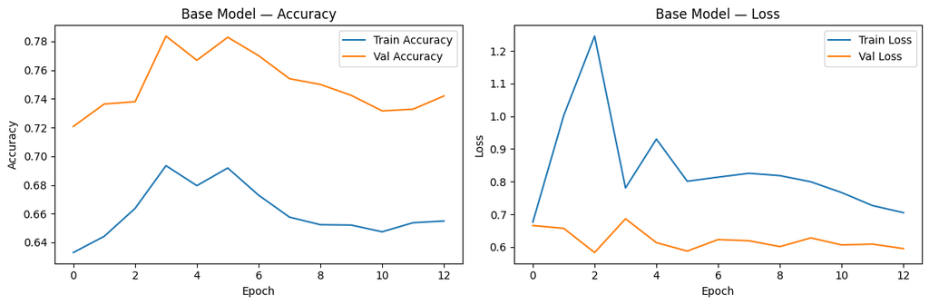

**Training summary — Base Model**

| Metric | Value |
| --- | --- |
| Best val accuracy | `0.7837` |
| Best val loss | `0.5830` |
| Final train acc | `0.6549` |
| Train / val gap | `-0.1287` — ✅ well generalised |
| Total epochs run | `13` |

```python
# ─── Apply the history helper to the Base Model run ──────────────────────────
# This will draw the accuracy/loss curves and print the summary table.
plot_history(base_history, titled='Base Model')
```